# Distributions (Part I)

### Bayesian Estimation (s27)

Let’s solve the above problem in Bayesian way. Beta distributions can be used to model the prior probability distribution of events. The beta distribution is the conjugate prior of the binomial distribution, and our problem is the binomial distribution problem, so the posterior distribution is also the beta distribution. In fact, the $\alpha$ and $\beta$ parameters of the beta distribution can be viewed as pseudocounts, which are added to the observed counts to reflect prior knowledge.(for more information about conjugate prior, see [this page](https://en.wikipedia.org/wiki/Conjugate_prior))

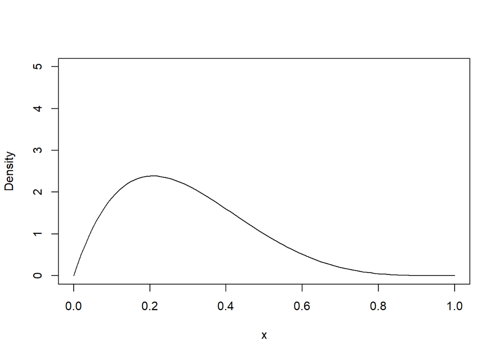

```r
# beta prior
alpha <- 2.0
beta <- 4.8
plot(seq(0,1,by = 0.01), dbeta(seq(0,1,by = 0.01), alpha, beta), type = "l",
     ylim = c(0, 5), xlim = c(0,1), ylab = "Density", xlab = "x")
```

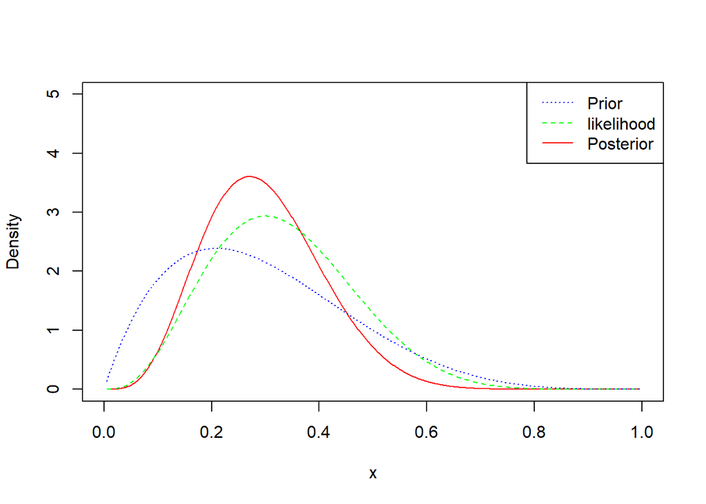

```r
# set the observed number of successes and failures.
n.success = 3  # number of bees follow the queen
n.failure = 7  # number of bees did not follow the queen

a = alpha + n.success  # convert to beta parameter
b = beta + n.failure   # convert to beta parameter

# with weak observation
theta <- seq(0.005, 0.995, length = 500)
plot(theta, dbeta(theta, a, b), type = "l", col = "red",
     ylim = c(0, 5), xlim = c(0,1), ylab = "Density", xlab = "x")
lines(theta, dbeta(theta, n.success + 1, n.failure + 1),
      lty = 2, col = "green")
lines(theta, dbeta(theta, alpha, beta), lty = 3, col = "blue")
legend("topright", legend = c("Prior", "likelihood", "Posterior"),
       col = c("blue", "green", "red"), lty = c(3, 2, 1))
```

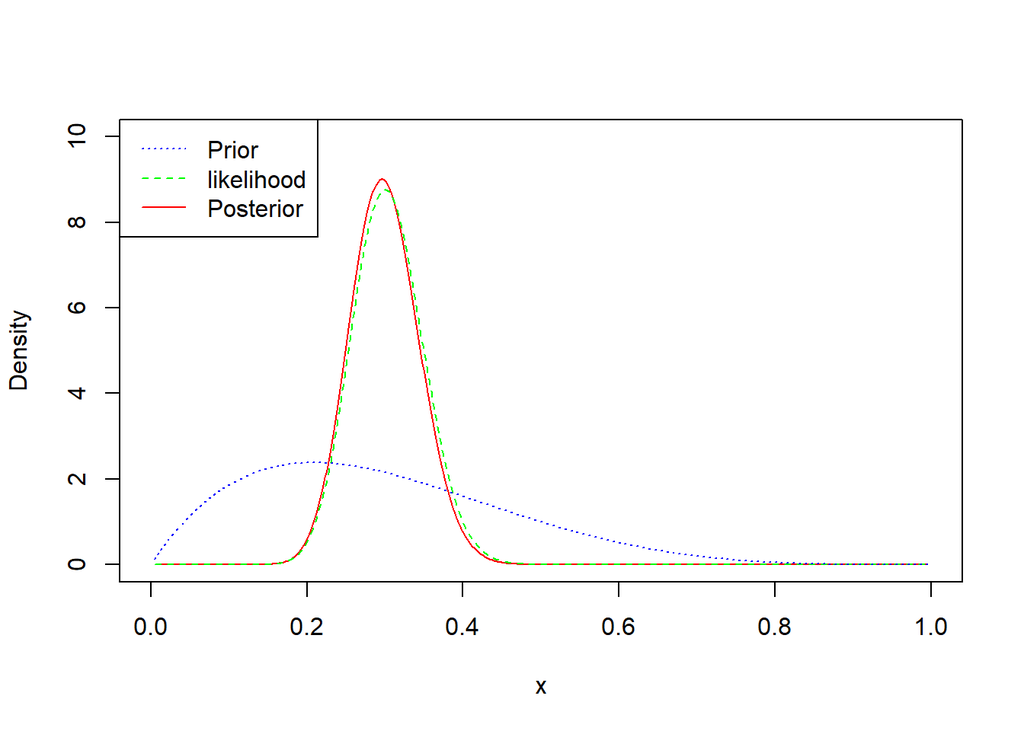

```r
# Add more observations
n.success = 30  # number of bees follow the queen
n.failure = 70  # number of bees did not follow the queen

a = alpha + n.success  # update parameter
b = beta + n.failure   # update parameter

# with strong observation
plot(theta, dbeta(theta, a, b), type = "l", col = "red",
     ylim = c(0, 10), xlim = c(0,1), ylab = "Density", xlab = "x")
lines(theta, dbeta(theta, n.success + 1, n.failure + 1),
      lty = 2, col = "green")
lines(theta, dbeta(theta, alpha, beta), lty = 3, col = "blue")
legend("topleft", legend = c("Prior", "likelihood", "Posterior"),
       col = c("blue", "green", "red"), lty = c(3, 2, 1))
```

### Bayesian Estimation using package - Advanced learner only (s27)

You can also use functions which provided by LearnBayes package

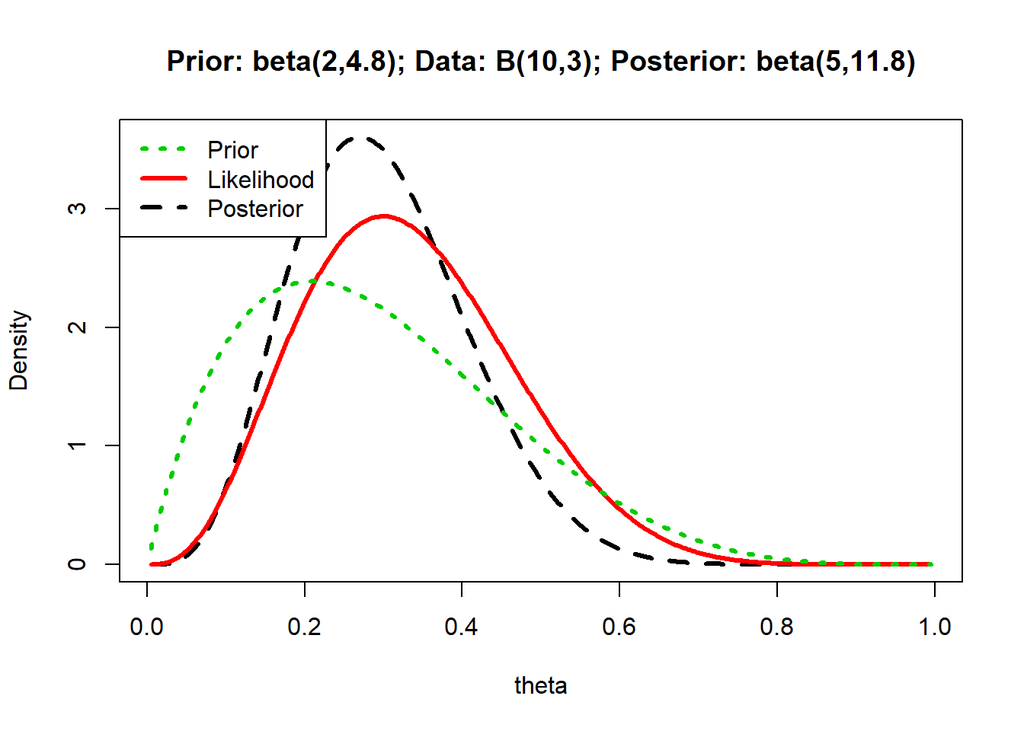

```
## [1] "Mode: prior= 0.208333333333333 ; Likelihood= 0.3 ; Posterior= 0.27027027027027"
## [1] "Mean: prior= 0.294117647058824 ; Likelihood= 0.333333333333333 ; Posterior= 0.297619047619048"
## [1] "~Approx Median (for a and b > 1): prior= 0.271739130434783 ; Likelihood= 0.323529411764706 , for Posterior= 0.289256198347107"
## [1] "Var: prior= 0.0266169816342827 ; Likelihood= 0.0170940170940171 ; Posterior= 0.0117439297816505"
## [1] "Skewness: prior= 4.63454509789934 ; Likelihood= 7.13714056959817 ; Posterior= 12.5096656156832"
```

```r
# install.packages("LearnBayes")
library(LearnBayes)

## calculate some properties of the Beta distribution
calcBetaMode = function(aa, bb) {
  beta.mode = (aa - 1)/(aa + bb - 2)
  return(beta.mode)
}
calcBetaMean = function(aa, bb) {
  beta.mean = (aa)/(aa + bb)
  return(beta.mean)
}
calcBetaVar = function(aa, bb) {
  beta.var = (aa * bb)/(((aa + bb)^2) * (aa + bb + 1))
  return(beta.var)
}
calcBetaMedian = function(aa, bb) {
  beta.med = (aa - 1/3)/(aa + bb - 2/3)
  return(beta.med)
}
calcBetaSkew = function(aa, bb) {
  beta.skew = (2 * (bb - aa) * sqrt(aa + bb + 1) ) / ((aa + bb + 2)/sqrt(aa + bb))
  return(beta.skew)
}


priorToPosterior = function(successes, total, a, b) {
  ## Note the rule of succession
  likelihood.a = successes + 1
  likelihood.b = total - successes + 1

  ## Create posterior
  posterior.a = a + successes;
  posterior.b = b + total - successes
  theta = seq(0.005, 0.995, length = 500)

  ## Calc density
  prior = dbeta(theta, a, b)
  likelihood = dbeta(theta, likelihood.a, likelihood.b)
  posterior = dbeta(theta, posterior.a, posterior.b)

  ## Plot prior, likelihood, and posterior

  ## Can be used to scale down the graph if desired.
  ## However, the density is different for each prior, likelihood, posterior
  m.orig = apply( cbind(prior, likelihood, posterior), 2, max)
  m = max(c(prior, likelihood, posterior))

  plot(theta, posterior, type = "l", ylab = "Density", lty = 2, lwd = 3,
       main = paste("Prior: beta(", round(a,2), ",", round(b,2), "); Data: B(", total, ",", successes, "); ",
                    "Posterior: beta(", round(posterior.a,2), ",", round(posterior.b,2), ")", sep = ""), ylim = c(0, m), col = 1)
  lines(theta, likelihood, lty = 1, lwd = 3, col = 2)
  lines(theta, prior, lty = 3, lwd = 3, col = 3)
  legend("topleft",y = m, c("Prior", "Likelihood", "Posterior"), lty = c(3, 1, 2),
         lwd = c(3, 3, 3), col = c(3, 2, 1))

  prior.mode = calcBetaMode(a, b)
  likelihood.mode = calcBetaMode(likelihood.a, likelihood.b)
  posterior.mode = calcBetaMode(posterior.a, posterior.b)
  prior.mean = calcBetaMean(a, b)
  likelihood.mean = calcBetaMean(likelihood.a, likelihood.b)
  posterior.mean = calcBetaMean(posterior.a, posterior.b)
  prior.med = calcBetaMedian(a, b)
  likelihood.med = calcBetaMedian(likelihood.a, likelihood.b)
  posterior.med = calcBetaMedian(posterior.a, posterior.b)
  prior.var = calcBetaVar(a, b)
  likelihood.var = calcBetaVar(likelihood.a, likelihood.b)
  posterior.var = calcBetaVar(posterior.a, posterior.b)
  prior.skew = calcBetaSkew(a, b)
  likelihood.skew = calcBetaSkew(likelihood.a, likelihood.b)
  posterior.skew = calcBetaSkew(posterior.a, posterior.b)

  print(paste("Mode: prior=",prior.mode,"; Likelihood=",likelihood.mode,"; Posterior=",posterior.mode))
  print(paste("Mean: prior=",prior.mean,"; Likelihood=",likelihood.mean,"; Posterior=",posterior.mean))
  print(paste("~Approx Median (for a and b > 1): prior=",prior.med,"; Likelihood=",likelihood.med,", for Posterior=",posterior.med))
  print(paste("Var: prior=",prior.var,"; Likelihood=", likelihood.var,"; Posterior=",posterior.var))
  print(paste("Skewness: prior=",prior.skew,"; Likelihood=",likelihood.skew,"; Posterior=",posterior.skew))
  return(list(a = posterior.a,b = posterior.b))
}

# calculate posterior for proportion
calcPosteriorForProportion <- function(successes, total, a, b)
{
  # Adapted from triplot() in the LearnBayes package
  # Plot the prior, likelihood and posterior:
  likelihood_a = successes + 1; likelihood_b = total - successes + 1
  posterior_a = a + successes;  posterior_b = b + total - successes
  theta = seq(0.005, 0.995, length = 500)
  prior = dbeta(theta, a, b)
  likelihood = dbeta(theta, likelihood_a, likelihood_b)
  posterior  = dbeta(theta, posterior_a, posterior_b)
  m = max(c(prior, likelihood, posterior))
  plot(theta, posterior, type = "l", ylab = "Density", lty = 2, lwd = 3,
       main = paste("beta(", a, ",", b, ") prior, B(", total, ",", successes, ") data,",
                    "beta(", posterior_a, ",", posterior_b, ") posterior"), ylim = c(0, m), col = "red")
  lines(theta, likelihood, lty = 1, lwd = 3, col = "blue")
  lines(theta, prior, lty = 3, lwd = 3, col = "green")
  legend(x = 0.8, y = m, c("Prior", "Likelihood", "Posterior"), lty = c(3, 1, 2),
         lwd = c(3, 3, 3), col = c("green", "blue", "red"))
  # Print out summary statistics for the prior, likelihood and posterior:
  calcBetaMode <- function(aa, bb) { BetaMode <- (aa - 1)/(aa + bb - 2); return(BetaMode); }
  calcBetaMean <- function(aa, bb) { BetaMean <- (aa)/(aa + bb); return(BetaMean); }
  calcBetaSd   <- function(aa, bb) { BetaSd <- sqrt((aa * bb)/(((aa + bb)^2) * (aa + bb + 1))); return(BetaSd); }
  prior_mode      <- calcBetaMode(a, b)
  likelihood_mode <- calcBetaMode(likelihood_a, likelihood_b)
  posterior_mode  <- calcBetaMode(posterior_a, posterior_b)
  prior_mean      <- calcBetaMean(a, b)
  likelihood_mean <- calcBetaMean(likelihood_a, likelihood_b)
  posterior_mean  <- calcBetaMean(posterior_a, posterior_b)
  prior_sd        <- calcBetaSd(a, b)
  likelihood_sd   <- calcBetaSd(likelihood_a, likelihood_b)
  posterior_sd    <- calcBetaSd(posterior_a, posterior_b)
  print(paste("mode for prior=",prior_mode,", for likelihood=",likelihood_mode,", for posterior=",posterior_mode))
  print(paste("mean for prior=",prior_mean,", for likelihood=",likelihood_mean,", for posterior=",posterior_mean))
  print(paste("sd for prior=",prior_sd,", for likelihood=",likelihood_sd,", for posterior=",posterior_sd))
}

# weak observation
n.success = 3  # number of bees follow the queen
n.failure = 7  # number of bees did not follow the queen

posterior.out = priorToPosterior(n.success, n.success + n.failure, alpha, beta)
```

```r
# Add more observations
n.success = 30  # number of bees follow the queen
n.failure = 70  # number of bees did not follow the queen

posterior.out = priorToPosterior(n.success, n.success + n.failure, alpha, beta)
```

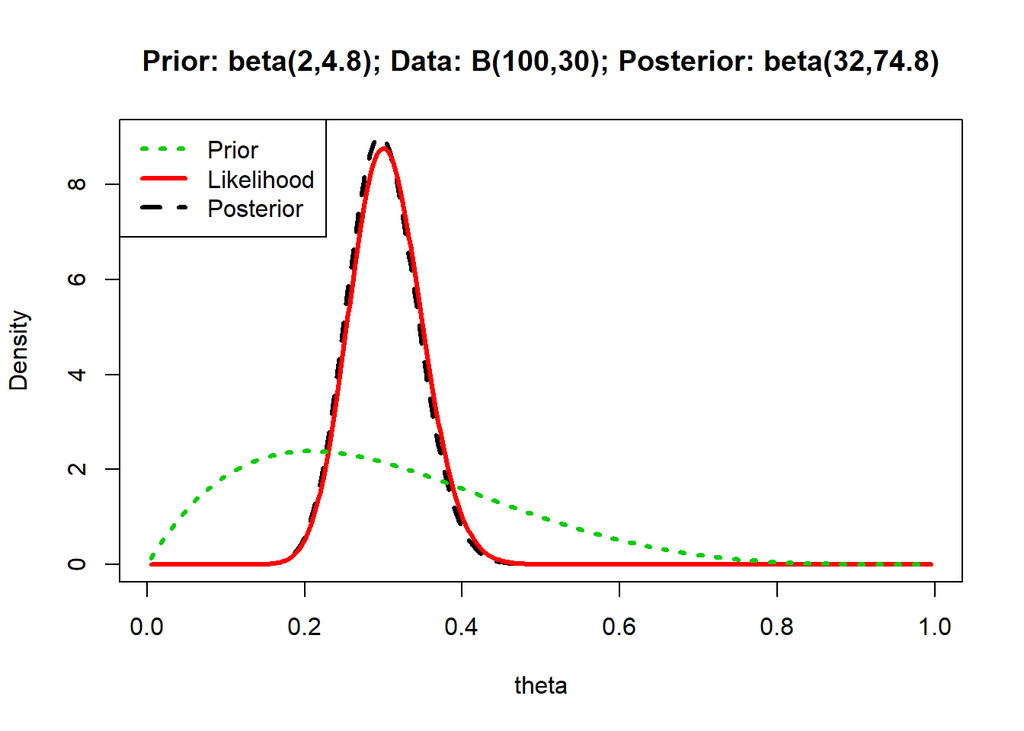

```
## [1] "Mode: prior= 0.208333333333333 ; Likelihood= 0.3 ; Posterior= 0.295801526717557"
## [1] "Mean: prior= 0.294117647058824 ; Likelihood= 0.303921568627451 ; Posterior= 0.299625468164794"
## [1] "~Approx Median (for a and b > 1): prior= 0.271739130434783 ; Likelihood= 0.302631578947368 , for Posterior= 0.298366834170854"
## [1] "Var: prior= 0.0266169816342827 ; Likelihood= 0.00205391503641243 ; Posterior= 0.00194666091829148"
## [1] "Skewness: prior= 4.63454509789934 ; Likelihood= 78.8452157542693 ; Posterior= 84.4189363883143"
```